# Regression Priors

Jim Albert

7/23/2017

#### A Baseball Example

The new Statcast system collects new types of baseball data. For each ball put into play, they collect the

- speed off the bat (called the Exit Velocity)
- vertical angle off the bat (called the Launch Angle)

Generally, it is believed that harder-hit balls and balls hit with the “right” launch angle are more likely to be base hits (as opposed to outs). Specifically, it is desirable that the batter hit a “line drive” which corresponds to a launch angle between 10 and 25 degrees.

#### Regression Model

These comments motivate the following regression model.

Let $y = 1 (0)$ be the response, where a 1 corresponds to a hit and 0 corresponds to an out.

Let $p$ denote the probability of a hit, that is, $P(y = 1)$.

A logistic model writes that the logit of the probability is a linear function:

$$\log \frac{p}{1-p} = \beta_0 + \beta_1 SPEED + \beta_2 I(LINE \, \, DRIVE)$$
where $SPEED$ is the launch velocity and $I(LINE \, \, DRIVE)$ is an indicator function which is equal to 1 if the hit is a line drive or 0 otherwise.

#### Standardizing Predictors and Model Interpretation

For purposes of interpreting the regression coefficients, it is helpful to reexpress any continuous-valued inputs. So we will standarize $SPEED$ to a z-score:

$$SPEED^* = \frac{SPEED - \bar x}{s_x}$$
and consider the model

$$\log \frac{p}{1-p} = \beta_0 + \beta_1 SPEED^* + \beta_2 I(LINE \, \, DRIVE)$$
With this new model, the regression parameters have clear interpretations:

- $\beta_0$ is the logit probability of a hit for a ball hit of average speed and **not** a line drive
- $\beta_1$ is the increase (on the logit scale) of the hit probability if the speed increases by one standard deviation when the type of hit (line drive or not) is fixed
- $\beta_2$ is the increase (on the logit scale) of the hit probability if a line drive is hit (over not a line drive) when the speed is fixed

Here is a fit of this model, shown graphically:

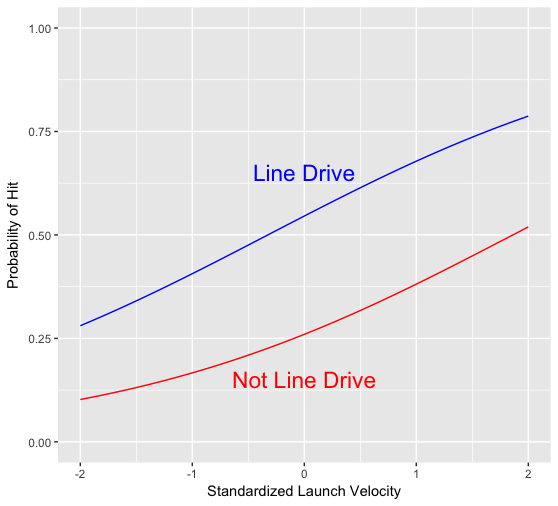

#### Prior Information

If you are a baseball fan, what prior information would you have about the regression coefficients?

- P1: You likely have some knowledge about the proportion of balls in play for non-line drives – this gives one information about the model intercept $\beta_0$
- P2: You believe that harder hit balls more likely will be hits which means that $\beta_1 > 0$.
- P3: Similarly, you believe that it is more likely to get a hit on a line drive, so $\beta_2 > 0$
- It may be reasonable to assume that your beliefs about $\beta_0$, $\beta_1$, and $\beta_2$ are independent – then you just need to specify the prior densities $g(\beta_0)$, $g(\beta_1)$, and $g(\beta_2)$
- Since all of the coefficients are real-valued, it is reasonable to assign each regression coefficient a $N(a, b)$ prior where $a$ is a “best guess” and $(a - 2b, a + 2b)$ is an interval that you’re pretty confident contains the coefficient

#### Default Priors

The `rstanarm` package supplies the following default (“weakly informative”) priors on the regression coefficients.

- The intercept $\beta_0$ (after the predictors are standardized) is assumed normal with mean 0 and standard deviation 10.
- Each of the standardized coefficients are assumed normal with mean 0 and standard deviation 2.5.

Generally these priors are conservative in the sense that they have larger standard deviations that one would typically use if one had informative prior beliefs about these regression coefficients.

#### Flat Priors?

It is common to recommend the use of “flat” priors in the case where one has little prior information about the locations of the coefficients. In other words, one could assign the improper prior of the form
$$g(\beta_0, \beta_1, \beta_2) = c$$
where $c$ is a constant. In most cases, the posterior distribution will be proper and one can perform inferences about the regression coeffficients.

There are several reasons not to use flat priors.

1. In some situations, say in this logistic model problem, where the use of an improper flat prior can lead to an improper posterior which is a problem.
2. The authors of the `rstanarm` package argue that flat priors are unrealistic in that they place much of the probability mass on sets of unrealistic parameter values.

#### Using `rstanarm` package with informative priors

I load in the `mystatcast` package that contains some Statcast data for the 2015 season. Also I load in the `dplyr` package for some data handling operations.

```r
library(mystatcast)
library(dplyr)
```

Standardize the exit velocity variable, and define the line drive and hit variables.

```r
mutate(scdata,
    s_velocity = scale(Exit_Velocity),
    line_drive = ifelse(Launch_Angle > 10 &
                      Launch_Angle < 25, 1, 0),
       hit = ifelse(Event %in%
c("Single", "Double", "Triple", "Home Run"), 1, 0)) ->
scdata
```

Remove home runs and take a random sample of the rows.

```r
scdata_ip <- filter(scdata, Event != "Home Run")
scdata_sample <- sample_n(scdata_ip, size=500)
```

#### Using the Default Priors

Fit the logistic model using Stan using the default priors.

```r
library(rstanarm)
bfit <- stan_glm(hit ~ s_velocity + line_drive,
            data=scdata_sample, family=binomial)
```

[output not shown]

[output cut: 40 more lines]

[output not shown]

What are the default priors?

```r
prior_summary(bfit)
```

```
## Priors for model 'bfit'
## ------
## Intercept (after predictors centered)
##  ~ normal(location = 0, scale = 10)
##
## Coefficients
##  ~ normal(location = [0,0], scale = [2.5,2.5])
##      **adjusted scale = [2.50,2.50]
## ------
## See help('prior_summary.stanreg') for more details
```

#### Using Your Own Priors

Instead suppose you want to assign the following priors to $\beta_1$ and $\beta_2$:
$$\beta_1 \sim N(0.3, 0.2), \, \, \beta_2 \sim N(0.7, 0.2)$$
Define these priors by use of the `normal` function in the `rstanarm` package.

```r
my_prior <- normal(location=c(0.3, 0.7),
                   scale=c(0.2, 0.2),
                   autoscale = FALSE)
```

Then you can use this prior in the `stan_glm` function using the `prior` argument.

```
bfit2 <- stan_glm(hit ~ s_velocity + line_drive,
                 data=scdata_sample,
                 prior=my_prior,
                 family=binomial)
```